# Prediction Assignment Writeup

JCombari

December 20, 2016

## Background

Using devices such as Jawbone Up, Nike FuelBand, and Fitbit it is now possible to collect a large amount of data about personal activity relatively inexpensively. These type of devices are part of the quantified self movement - a group of enthusiasts who take measurements about themselves regularly to improve their health, to find patterns in their behavior, or because they are tech geeks. One thing that people regularly do is quantify how much of a particular activity they do, but they rarely quantify how well they do it. In this project, your goal will be to use data from accelerometers on the belt, forearm, arm, and dumbell of 6 participants. They were asked to perform barbell lifts correctly and incorrectly in 5 different ways. More information is available from the website here: http://groupware.les.inf.puc-rio.br/har (see the section on the Weight Lifting Exercise Dataset).

### Goal

The goal of this project is to predict the manner in which they did the exercise. This is the “classe” variable in the training set. We may use any of the other variables to predict with. We should create a report describing how you built your model, how we used cross validation, what we think the expected out of sample error is, and why we made the choices we did. we will also use your prediction model to predict 20 different test cases.

## Loading packages

```r
library(caret)
library(rpart)
library(rpart.plot)
library(RColorBrewer)
library(rattle)
library(randomForest)
library(knitr)
```

## Loading the data

The training data for this project are available here:

https://d396qusza40orc.cloudfront.net/predmachlearn/pml-training.csv

The test data are available here:

https://d396qusza40orc.cloudfront.net/predmachlearn/pml-testing.csv

```r
training1 <- "http://d396qusza40orc.cloudfront.net/predmachlearn/pml-training.csv"
testing1 <- "http://d396qusza40orc.cloudfront.net/predmachlearn/pml-testing.csv"
```

## Loading data to memory

```r
training <- read.csv(url(training1), na.strings=c("NA","#DIV/0!",""))
testing <- read.csv(url(testing1), na.strings=c("NA","#DIV/0!",""))
```

## Data cleaning

We now delete columns (predictors) of the training set that contain any missing values.

```r
training <- training[, colSums(is.na(training)) == 0]
testing <- testing[, colSums(is.na(testing)) == 0]
```

The training dataset contains 60 variables with 19622 observations, and the testing dataset contains 20 observations to test the performance of prediction of the classification model.

```r
dim(training)
```

```
## [1] 19622    60
```

```r
dim(testing)
```

```
## [1] 20 60
```

## Data Partitioning

Split data into training/testing sets

```r
inTrain <- createDataPartition(y=training$classe, p=0.6, list=FALSE)
myTraining <- training[inTrain, ]; myTesting <- training[-inTrain, ]
dim(myTraining); dim(myTesting)
```

```
## [1] 11776    60
```

```
## [1] 7846   60
```

The new training dataset contains 60 variables with 11776 observations, and the new testing dataset contains 7846 observations to test the performance of prediction of the classification model.

[output not shown]

## Model Building

### Prediction with Decision Trees (or Classification trees)

In practice,k=10 when doing k-fold cross validation.

### fit the model

[figure not shown]

```r
modFitA1 <- rpart(classe ~ ., data=myTraining, method="class")
fancyRpartPlot(modFitA1)
```

```r
predictionsA1 <- predict(modFitA1, myTesting, type = "class")
cmtree <- confusionMatrix(predictionsA1, myTesting$classe)
cmtree
```

```
## Confusion Matrix and Statistics
##
##           Reference
## Prediction    A    B    C    D    E
##          A 2153   55    6    1    0
##          B   60 1254   82   59    0
##          C   19  196 1260  151   63
##          D    0   13   20 1016  183
##          E    0    0    0   59 1196
##
## Overall Statistics
##
##                Accuracy : 0.8768
##                  95% CI : (0.8693, 0.8839)
##     No Information Rate : 0.2845
##     P-Value [Acc > NIR] : < 2.2e-16
##
##                   Kappa : 0.8442
##  Mcnemar's Test P-Value : NA
##
## Statistics by Class:
##
##                      Class: A Class: B Class: C Class: D Class: E
## Sensitivity            0.9646   0.8261   0.9211   0.7900   0.8294
## Specificity            0.9890   0.9682   0.9338   0.9671   0.9908
## Pos Pred Value         0.9720   0.8619   0.7460   0.8247   0.9530
## Neg Pred Value         0.9860   0.9587   0.9825   0.9592   0.9627
## Prevalence             0.2845   0.1935   0.1744   0.1639   0.1838
## Detection Rate         0.2744   0.1598   0.1606   0.1295   0.1524
## Detection Prevalence   0.2823   0.1854   0.2153   0.1570   0.1600
## Balanced Accuracy      0.9768   0.8972   0.9274   0.8786   0.9101
```

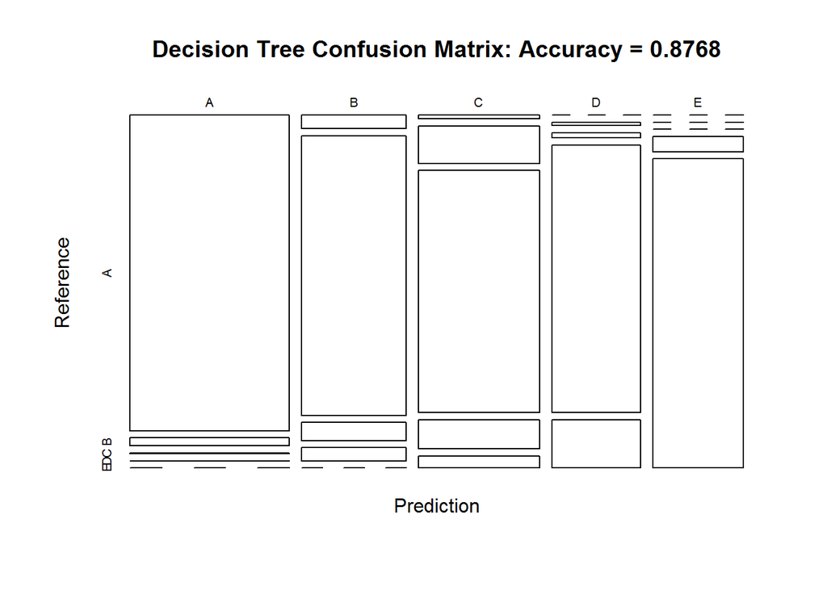

```r
plot(cmtree$table, col = cmtree$byClass, main = paste("Decision Tree Confusion Matrix: Accuracy =", round(cmtree$overall['Accuracy'], 4)))
```

### Random Forest

```r
modFitB1 <- randomForest(classe ~ ., data=myTraining)
predictionB1 <- predict(modFitB1, myTesting, type = "class")

cmrf <- confusionMatrix(predictionB1, myTesting$classe)
cmrf
```

```
## Confusion Matrix and Statistics
##
##           Reference
## Prediction    A    B    C    D    E
##          A 2231    0    0    0    0
##          B    1 1518    6    0    0
##          C    0    0 1362    4    0
##          D    0    0    0 1281    3
##          E    0    0    0    1 1439
##
## Overall Statistics
##
##                Accuracy : 0.9981
##                  95% CI : (0.9968, 0.9989)
##     No Information Rate : 0.2845
##     P-Value [Acc > NIR] : < 2.2e-16
##
##                   Kappa : 0.9976
##  Mcnemar's Test P-Value : NA
##
## Statistics by Class:
##
##                      Class: A Class: B Class: C Class: D Class: E
## Sensitivity            0.9996   1.0000   0.9956   0.9961   0.9979
## Specificity            1.0000   0.9989   0.9994   0.9995   0.9998
## Pos Pred Value         1.0000   0.9954   0.9971   0.9977   0.9993
## Neg Pred Value         0.9998   1.0000   0.9991   0.9992   0.9995
## Prevalence             0.2845   0.1935   0.1744   0.1639   0.1838
## Detection Rate         0.2843   0.1935   0.1736   0.1633   0.1834
## Detection Prevalence   0.2843   0.1944   0.1741   0.1637   0.1835
## Balanced Accuracy      0.9998   0.9994   0.9975   0.9978   0.9989
```

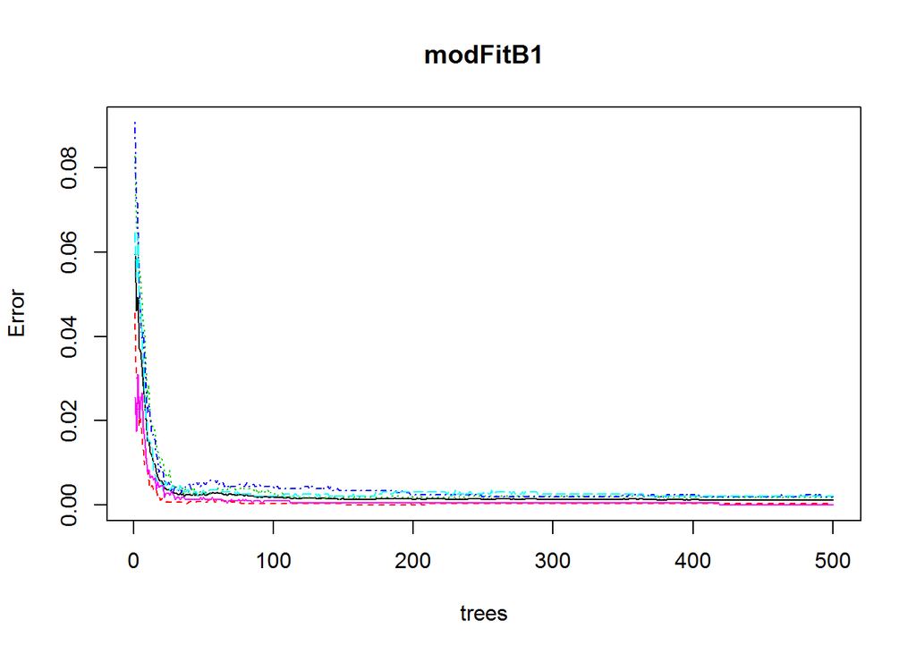

```r
plot(modFitB1)
```

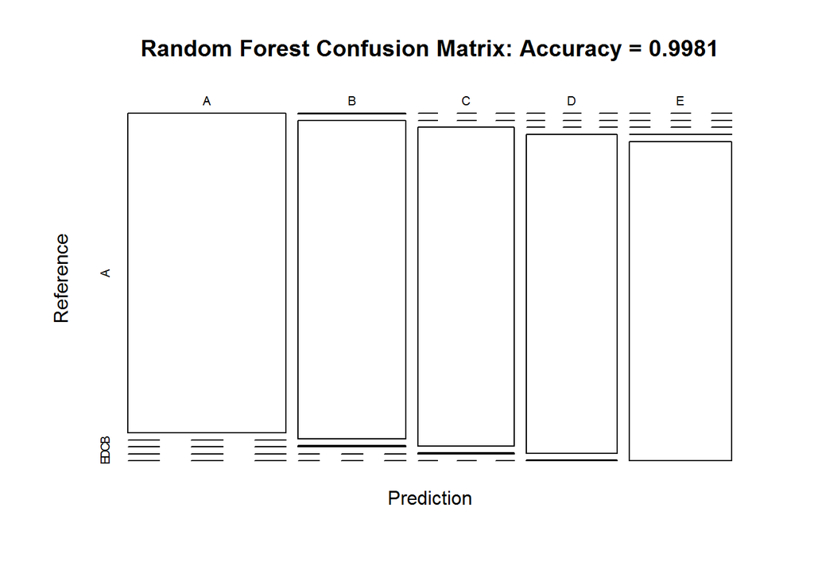

```r
plot(cmrf$table, col = cmtree$byClass, main = paste("Random Forest Confusion Matrix: Accuracy =", round(cmrf$overall['Accuracy'], 4)))
```

### Course Project Prediction Quiz Portion

We going to apply our machine learning algorithm to the 20 test cases available in the test data above

```r
predictionsB2 <- predict(modFitB1, testing, type = "class")
```

and submit the predictions in appropriate format to the Course Project Prediction Quiz for automated grading.

```r
pml_write_files = function(x){
  n = length(x)
  for(i in 1:n){
    filename = paste0("prediction_id_",i,".txt")
    write.table(x[i],file=filename,quote=FALSE,row.names=FALSE,col.names=FALSE)
  }
}

pml_write_files(predictionsB2)
```

### Conclusion

From the information shown above we can conclude that the Random forest classification technique works better than a regression tree in this case.

The results that was obtained by using random forest technique were highly accurate on the testing set.